# Atividades - Criando R Markdown e Website

# Atividade 4 - R Markdown

A atividade 4 consistiu na criação de um arquivo R Markdown no RStudio. O documento criado inicialmente contêm alguns exemplos de texto e `chunks`.

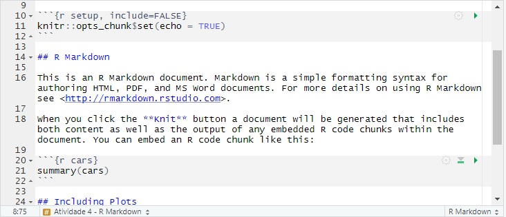

O documento em R Markdown foi reorganizado seguindo as instruções da Aula 4, substituindo-se os `chunks`do arquivo raiz pelos comandos e formulações necessárias para criação de um arquivo HTML.

Este arquivo HTML consistirá nas explicações detalhadas de como elaboramos a Atividade 3, na qual tivemos de acessar os bancos de dados do GBIF e OBIS.

## 1. Em busca da Moby Dick

[figure not shown]

Figura representando a famosa “baleia branca” do clássico Moby Dick

A espécie escolhida para esta atividade foi *Physeter macrocephalus*, conhecida popularmente como cachalote. Essa espécie é o maior representante dos odontocetos (baleias com dentes) e apresentam dimorfismo sexual onde os machos adultos podem atingir 16 metros e pesar 45 toneladas, enquanto as fêmeas chegam a 11 metros e podem pesar até 15 toneladas.

As populações de *P. macrocephalus* sofreram grande impacto com a caça às baleias desde o século 18, na qual os marinheiros capturavam as baleias para extrair seu óleo corporal muito utilizado na iluminação pública e construção civil da época. No entanto, essa prática se perpetuou pelos séculos seguintes elevando essa espécie a categoria EN (Em Perigo) pela Lista Vermelha da União Internacional para Conservação da Natureza (IUCN).

As maiores capturas, cerca de 900.000 individuos, ocorreram na era “moderna” utilizando-se grandes embarcações motorizadas e técnicas sofisticadas de caça. Essas capturas diminuiram após a moratória imposta pela Comissão Baleeira Internacional (IWC) direcionada à caça comercial das baleias. Apesar de todos esses problemas as cachalotes ainda são as mais abundantes (dentre as grandes baleias), apresentando uma distribuição global, habitando preferencialmente águas com profundidade acima de 200 metros.

## 2. Coletando dados do GBIF

Antes de coletar os dados carregamos os pacotes `dplyr`, `tidyverse` e `rgbif`. Em seguida, iniciamos o download das ocorrências da espécie P. macrocephalus existentes no banco de dados GBIF, utilzando a função `occ_data` que realiza uma busca simples das ocorrências da nossa espécie no repositório.

```
   ## checar funcoes
    ?occ_data
   ## baixar ocorrencias
    cacha_gbif <- occ_data(scientificName = "Physeter macrocephalus",
                           hasCoordinate = TRUE,
                           hasGeospatialIssue=FALSE)

   ## dimensoes

    dim(cacha_gbif)

   ## NULL
```

O download foi realizado aplicamos a função abaixo para identificar as dimensões dos dados referentes a *P. macracephalus*. Neste repositório nossa espécie contem um arquivo com 500 linhas e 130 colunas

```
    dim(cacha_gbif$data)
```

```
## [1] 500 130
```

Em seguida, checamos os campos existentes nos dados `cacha_gbif`, utilizando o seguinte comando:

```
# checar campos
cacha_gbif$data %>% names

 ## [1] "key"
 ## [2] "scientificName"
 ## [3] "decimalLatitude"
 ## [4] "decimalLongitude"
 ## [5] "issues"
 ## [6] "datasetKey"
 ## [7] "publishingOrgKey"
 ## [8] "installationKey"
 ## [9] "publishingCountry"
 ## [10] "protocol"
 ## [11] "lastCrawled"
 ## [12] "lastParsed"
 ## [13] "crawlId"
 ## [14] "hostingOrganizationKey"
 ## [15] "basisOfRecord"
 ## [16] "individualCount"
 ## [17] "occurrenceStatus"
 ## [18] "sex"
 ## [19] "taxonKey"
 ## [20] "kingdomKey"
 ## [21] "phylumKey"
 ## [22] "classKey"
 ## [23] "orderKey"
 ## [24] "familyKey"
 ## [25] "genusKey"
 ## [26] "speciesKey"
 ## [27] "acceptedTaxonKey"
 ## [28] "acceptedScientificName"
 ## [29] "kingdom"
 ## [30] "phylum"
 ## [31] "order"
 ## [32] "family"
 ## [33] "genus"
 ## [34] "species"
 ## [35] "genericName"
 ## [36] "specificEpithet"
 ## [37] "taxonRank"
 ## [38] "taxonomicStatus"
 ## [39] "iucnRedListCategory"
 ## [40] "continent"
 ## [41] "year"
 ## [42] "month"
 ## [43] "day"
 ## [44] "eventDate"
 ## [45] "lastInterpreted"
 ## [46] "license"
 ## [47] "isInCluster"
 ## [48] "geodeticDatum"
 ## [49] "class"
 ## [50] "countryCode"
 ## [51] "country"
 ## [52] "identifier"
 ## [53] "recordedBy"
 ## [54] "locality"
 ## [55] "occurrenceRemarks"
 ## [56] "collectionCode"
 ## [57] "gbifID"
 ## [58] "verbatimLocality"
 ## [59] "occurrenceID"
 ## [60] "taxonRemarks"
 ## [61] "dateIdentified"
 ## [62] "coordinateUncertaintyInMeters"
 ## [63] "stateProvince"
 ## [64] "modified"
 ## [65] "references"
 ## [66] "rightsHolder"
 ## [67] "http://unknown.org/nick"
 ## [68] "informationWithheld"
 ## [69] "verbatimEventDate"
 ## [70] "datasetName"
 ## [71] "taxonID"
 ## [72] "catalogNumber"
 ## [73] "http://unknown.org/occurrenceDetails"
 ## [74] "institutionCode"
 ## [75] "rights"
 ## [76] "eventTime"
 ## [77] "identifiedBy"
 ## [78] "identificationID"
 ## [79] "networkKeys"
 ## [80] "institutionID"
 ## [81] "nomenclaturalCode"
 ## [82] "island"
 ## [83] "preparations"
 ## [84] "dynamicProperties"
 ## [85] "municipality"
 ## [86] "county"
 ## [87] "associatedReferences"
 ## [88] "locationID"
 ## [89] "fieldNotes"
 ## [90] "behavior"
 ## [91] "lifeStage"
 ## [92] "identificationRemarks"
 ## [93] "coordinatePrecision"
 ## [94] "waterBody"
 ## [95] "type"
 ## [96] "vernacularName"
 ## [97] "georeferencedDate"
 ## [98] "recordNumber"
 ## [99] "footprintWKT"
 ## [100] "ownerInstitutionCode"
 ## [101] "datasetID"
 ## [102] "bibliographicCitation"
 ## [103] "institutionKey"
 ## [104] "language"
 ## [105] "taxonConceptID"
 ## [106] "higherGeography"
 ## [107] "http://unknown.org/taxonRankID"
 ## [108] "georeferenceProtocol"
 ## [109] "disposition"
 ## [110] "samplingProtocol"
 ## [111] "http://unknown.org/species"
 ## [112] "higherClassification"
 ## [113] "organismID"
 ## [114] "organismRemarks"
 ## [115] "eventID"
 ## [116] "http://unknown.org/license"
 ## [117] "identificationVerificationStatus"
 ## [118] "http://unknown.org/rightsHolder"
 ## [119] "organismQuantity"
 ## [120] "organismQuantityType"
 ## [121] "http://rs.tdwg.org/dwc/terms/organismQuantity"
 ## [122] "http://rs.tdwg.org/dwc/terms/organismQuantityType"
 ## [123] "http://unknown.org/northing"
 ## [124] "locationRemarks"
 ## [125] "http://unknown.org/easting"
 ## [126] "reproductiveCondition"
 ## [127] "http://unknown.org/zone"
 ## [128] "dataGeneralizations"
 ## [129] "eventRemarks"
 ## [130] "name"
```

Acima podemos observar as variáveis do conjunto de dados disponiveis no repositório GBIF para as ocorrências de cachalote.

## 3. Checando problemas nos dados obtidos

### 3.1 Problemas reportados

Os problemas reportados são uma ferramenta importante para aplicarmos filtros e melhorar a qualidade dos dados capturados no repositório. A coluna denominada `issues` apresenta problemas identificados de forma automática do repositório. Verificamos esses problemas e os códigos por meio da função `gbif_issues`.

```
    # Checar issus

    gbif_issues()
```

Ao executar a função acima gerou-se uma lista com os diversos problemas identificados e suas respectivas descrições. Utilizamos a função `strsplit` para individualizar os `issues` e observar quais os problemas nos dados da nossa espécie.

```
    # checar os issues individuais da espécie

    issues_gbif <- cacha_gbif$data$issues %>%
      # unique() %>%
      strsplit(.,"[,]") %>%
      unlist() %>%
      unique()
```

```
issues_gbif

## [1] "osiic"
## [2] "cdround"
## [3] "inmano"
## [4] "gass84"
## [5] "cudc"
## [6] "fpwktinv"
## [7] "colmano"
## [8] "inmafu"
## [9] "gdativ"
```

Foram encontrados 9 tipos de issues, os quais estão descritos abaixo:

```
#48       osiic  OCCURRENCE_STATUS_INFERRED_FROM_INDIVIDUAL_COUNT
#10     cdround                                COORDINATE_ROUNDED
#58      inmano                            INSTITUTION_MATCH_NONE
#23      gass84                      GEODETIC_DATUM_ASSUMED_WGS84
#12        cudc                  COUNTRY_DERIVED_FROM_COORDINATES
#63    fpwktinv                             FOOTPRINT_WKT_INVALID
#55     colmano                             COLLECTION_MATCH_NONE
#57      inmafu                           INSTITUTION_MATCH_FUZZY
#24      gdativ                            GEODETIC_DATUM_INVALID
```

Nenhum desses problemas parece invalidar as ocorrências de *P. macrocephalus*, seguimos então alguns campos que podem ser interessantes para a pesquisa sobre a espécie. Para tanto, utilizamos o código abaixo selecionando váriaveis como: nome científico, coordenadas da ocorrência, corpos de água e etc.

```
   # selecionar campos de interesse

    cacha_gbif1 <- cacha_gbif$data %>%
      dplyr::select(scientificName, decimalLatitude, decimalLongitude,issues,
                    basisOfRecord, sex, rightsHolder,
                    datasetName, recordedBy, waterBody, country)
```

Observe que temos 500 observações com as 11 variáveis selecionadas. Vejamos então quantas são **únicas**, utilizando a função `distinct` do pacote `dplyr`.

```
    # ocorrencias únicas
    cacha_gbif1 <- cacha_gbif1 %>%
      distinct()
```

Temos agora 452 observações únicas em nosso conjunto de dados `cacha_gbif1`. Em seguida, buscamos identificar os valores únicos nos dados aplicando a função `unique` para cada coluna em um *loop* na função `lapply`.

```
    # checar niveis dos fatores

    lapply(cacha_gbif1, unique)
```

```
## $scientificName
## [1] "Physeter macrocephalus Linnaeus, 1758"
## [2] "Physeter catodon Linnaeus, 1758"
##
## $decimalLatitude
##[1]  53.229740  57.038607 -42.513421  53.233444 -36.253753   3.172525   3.193708   3.182405   3.173467
##[10]   3.146190   3.046789   3.105529   3.067261   3.099359  69.529612  21.193178  20.864816 -38.443199
##[19] -34.666047 -34.694203 -34.650155 -34.668158 -38.530000 -42.583345  27.353921  40.355064   0.228051
##[28] -34.662017 -34.659722 -34.627558  36.941588  37.035517  36.970796  36.906790 -34.156041  69.414462
##[37]  72.055390 -42.687137  37.470764  37.540593  37.405967  37.404381 -46.413400  36.875517  53.145000
##[46]  38.388565  38.391527  38.396098  37.989720  37.814376  69.333318  43.766734  25.079536  38.096015
##[55]  37.954962  64.810520  43.940000  37.590567  42.996061  52.667470  43.049778  41.156506  69.399703
##[64]  37.694844  41.863016  38.654968  38.615930  38.689125 -37.503292  57.905753  36.076367  19.896102
##[73]  18.975035  20.829486 -42.437301  57.567727 -42.523676  57.213250 -34.942833 -34.936833 -35.779167
##[82] -34.972333 -34.945000 -34.919167 -34.952667 -34.777833 -34.768500 -35.686833  16.184533  32.664813
```

[output cut: 281 more lines]

### 3.2 Problemas não reportados

O próximo passo realizado foi a busca ativa por problemas que não tenham sido reportados automaticamente, até o momento. Esse processo de analise do conjunto de dados é necessário devido a incapacidade dos algoritimos de observar se uma determinada informação é de fato confiável ou está de acordo com as informações encontradas na literatura disponível.

Iniciaremos checando os países que foram relatadas ocorrências de indivíduos de cachalote:

```
    # investigar niveis suspeitos
    cacha_gbif1 %>%
      distinct(country) %>%
      pull()
```

```
## [1] "Netherlands"
## [2] "United Kingdom of Great Britain and Northern Ireland"
## [3] "New Zealand"
## [4] "Cameroon"
## [5] "Norway"
## [6] "Mexico"
## [7] "Australia"
## [8] "United States of America"
## [9] "Greece"
## [10] "Ecuador"
## [11] "South Africa"
## [12] "Portugal"
## [13] NA
## [14] "Italy"
## [15] "Iceland"
## [16] "France"
## [17] "Canada"
## [18] "Guadeloupe"
## [19] "Dominica"
## [20] "Honduras"
## [21] "Panama"
## [22] "Israel"
## [23] "Chinese Taipei"
## [24] "Japan"
## [25] "United States Minor Outlying Islands"
## [26] "Spain"
```

Nossa espécie teve relatos de ocorrência em 25 localidades. Utilizando a função `ggplot` iremos fazer um gráfico de barras apresentando as quantidades de relatos para os países mencionados:

```
    # country
    cacha_gbif1 %>%
      group_by(country) %>%
      summarise(occ = length(scientificName)) %>%
      ggplot(aes(occ, y=country)) +
      geom_bar(stat = 'identity')
```

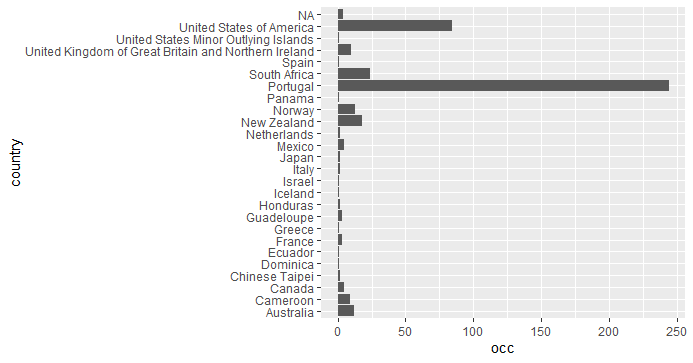

Podemos observar que nossa espécie apresenta ocorrência em diversos locais do planeta, o que é de fato registrado para a espécie analisada. Investigaremos agora a possibilidade de divergências no nome da espécie.

```
    # investigar divergência do nome da científico
    cacha_gbif1 %>%
      distinct(scientificName) %>%
      pull()
```

```
## [1] "Physeter macrocephalus Linnaeus, 1758"
## [2] "Physeter catodon Linnaeus, 1758"
```

Foram encontrados relatos de duas espécies do gênero Physeter. Como o nosso intuito é analisar apenas a espécie macrocephalus iremos rastrear a fonte e remover do nosso conjunto de dados.

```
    cacha_gbif1 %>%
      distinct(basisOfRecord) %>%
      pull()
```

Primeiramente, distinguimos a base na qual os dados foram registrados e encontramos as 4 bases abaixo:

```
## [1] "HUMAN_OBSERVATION"
## [2] "PRESERVED_SPECIMEN"
## [3] "MATERIAL_SAMPLE"
## [4] "MACHINE_OBSERVATION"
```

Logo depois fizemos um gráfico de barras para saber a quantidade de ocorrências de casa base:

```
    # basisOfRecord
    cacha_gbif1 %>%
      group_by(basisOfRecord) %>%
      summarise(occ = length(scientificName)) %>%
      ggplot(aes(occ, y= basisOfRecord)) +
      geom_bar(stat = 'identity')
```

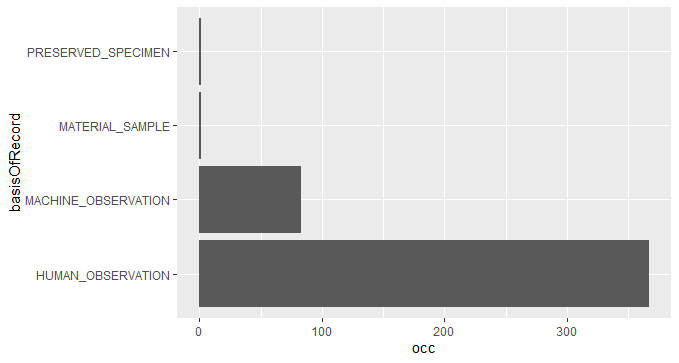

Olhando atentamente para a base “**PRESERVED_SPECIMEN**” encontramos apenas uma ocorrência da espécie *Physeter catodon*.

```
    # fonte das regioes erradas
    cacha_gbif1 %>%
      filter(scientificName %in% c("Physeter catodon Linnaeus, 1758")) %>%
      distinct(basisOfRecord)
```

```
## # A tibble: 1 x 1
##  basisOfRecord
##  <chr>
## 1 PRESERVED_SPECIMEN
```

O passo seguinte é observar mais de perto a ocorrência e por precaução excluir essa informação do nosso conjunto de dados:

```
    # 1 ocorrência
    cacha_gbif1 %>%
      filter(basisOfRecord %in% c("PRESERVED_SPECIMEN"))
```

```
## # A tibble: 1 x 11
##  scientificName     decimalLatitude decimalLongitude issues  basisOfRecord  sex   rightsHolder
##  <chr>             <dbl>            <dbl> <chr>   <chr>          <chr> <chr>
## 1 Physeter catodon ~            53.2             4.88 osiic,~ PRESERVED_SPE~ MALE  Naturalis Biod~
## # ... with 4 more variables: datasetName <chr>, recordedBy <chr>, waterBody <chr>, country <chr>
```

```
    # filtrar todas do dataset suspeito
    cacha_gbif_ok <- cacha_gbif1 %>%
      filter(!basisOfRecord %in% c("PRESERVED_SPECIMEN"))
```

Pronto! Nosso conjunto de dados `cacha_gbif_ok` contêm agora 451 observações. Vamos plotar as ocorrências de *Physeter macrocephalus*, mas antes precisamos carregar os pacotes `ggmap`, `maps` e `mapdata`.

```
    ## PLotar ocorrencias

    library(ggmap)
    library(maps)
    library(mapdata)

    world <- map_data('world')

    # checar pontos
    ggplot() +
      geom_polygon(data = world, aes(x = long, y = lat, group = group)) +
      coord_fixed() +
      theme_classic() +
      geom_point(data = cacha_gbif_ok,aes(x = decimalLongitude, y = decimalLatitude), color = "red") +
      labs(x = "longitude", y = "latitude", title = expression(italic("Physeter macrocephalus")))
```

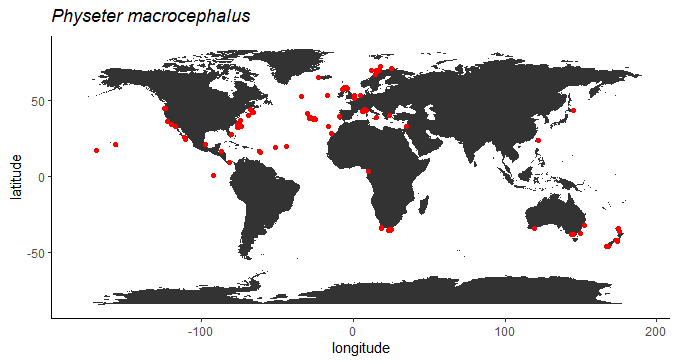

Como podemos ver no mapa acima nossa espécie apresenta ocorrência em todos os oceanos, mas será que sua distribuição não é maior? Para isso iremos acessar outro banco de dados e efetuar praticamente as mesmas funções. Vamos lá então!

## 4. Coletando dados do OBIS

Assim como o GBIF o repositório do **OBIS** está repleto de dados das diversas espécies, principalmente de espécies aquáticas. A fim de coletar os dados deste repositório iremos utilizar o pacote `robis` e a função `occurrence` deste mesmo pacote.

```
    # extrair dados do OBIS
    library(robis)
```

```
    # baixar ocorrências
    cacha_obis <- robis::occurrence("Physeter macrocephalus")
    # Retrieved 78838 records of approximately 78838 (100%)
```

Coletamos 78.838 observações divididas em 155 variáveis. Precisamos verificar os possiveis problemas checando os dados. Importante observar que neste repositório os problemas reportados são denominados de `flags`.

```
# checar dados
names(cacha_obis)

## [1] "date_year"                     "scientificNameID"
## [3] "year"                          "scientificName"
## [5] "superfamilyid"                 "dropped"
## [7] "aphiaID"                       "decimalLatitude"
## [9] "subclassid"                    "phylumid"
## [11] "familyid"                      "catalogNumber"
## [13] "occurrenceStatus"              "basisOfRecord"
## [15] "superclass"                    "modified"
## [17] "id"                            "order"
## [19] "superclassid"                  "infraorderid"
## [21] "dataset_id"                    "decimalLongitude"
## [23] "collectionCode"                "date_end"
```

[output cut: 66 more lines]

### 4.1 Problemas reportados

Antes mesmo de checarmos os problemas comumente reportados no repositório OBIS iremos selecionar as variáveis que possam ser mais úteis, de acordo com o nosso objetivo:

```
    cacha_obis1 <- cacha_obis %>%
      dplyr::select(scientificName, decimalLatitude, decimalLongitude, bathymetry,
                    flags, waterBody, basisOfRecord, occurrenceStatus, rightsHolder,
                    datasetName, recordedBy, depth, locality, habitat) %>%
      distinct()
```

Pronto, agora nosso conjunto de dados `cacha_obis1` contêm 48.157 observações e 14 variáveis. Vamos checar quais são os problemas reportados:

```
      # check problemas reportados (flags)
    cacha_obis1 %>%
      distinct(flags)
```

```
## # A tibble: 12 x 1
##   flags
##   <chr>
## 1 no_depth
## 2 NO_DEPTH
## 3 NA
## 4 ON_LAND,NO_DEPTH
## 5 no_depth,on_land
## 6 depth_exceeds_bath,on_land
## 7 on_land,no_depth
## 8 on_land
## 9 depth_exceeds_bath
## 10 on_land,depth_exceeds_bath
## 11 ON_LAND
## 12 ON_LAND,DEPTH_EXCEEDS_BATH
```

```
    # check NA em datasetName
    cacha_obis1 %>%
      filter(!flags %in% c("ON_LAND,NO_DEPTH", "no_depth,on_land", "depth_exceeds_bath,on_land", "on_land,no_depth", "on_land", "on_land,depth_exceeds_bath", "ON_LAND", "ON_LAND,DEPTH_EXCEEDS_BATH"),
             is.na(datasetName)) %>%
      distinct(waterBody)
```

```
## # A tibble: 10 x 1
##  waterBody
##   <chr>
## 1 NA
## 2 Southern Ocean
## 3 Arctic
## 4 South Pacific Ocean
## 5 Atlantic
## 6 Gulf of Mexico
## 7 South Pacific Ocean; Open waters
## 8 Atlantic Ocean
## 9 Isla de Malpelo
## 10 Pacifc Ocean
```

As `flags` foram utilizadas para filtrar ocorrências da nossa espécie em terra e remover do nosso conjunto de dados os *dataset* que apresentaram não apresentaram informações (NA). Além disso, aplicamos um filtro para remover a duplicidade de ocorrências no Oceano Pacífico e plotamos um gráfico verificando as profundidades relatadas:

[output not shown]

Após a checagem dos níveis aplicamos mais uma vez o filtro, tornando nosso conjunto de dados mais confiável.

```
    # aplicação final do filtro
    cacha_obis_ok <- cacha_obis1 %>%
      filter(!flags %in% c("ON_LAND,NO_DEPTH","no_depth,on_land","depth_exceeds_bath,on_land","on_land,no_depth", "on_land", "on_land,depth_exceeds_bath", "ON_LAND", "ON_LAND,DEPTH_EXCEEDS_BATH"),
             !is.na(datasetName),
             !waterBody %in% c("South Pacific Ocean; Open waters", "world"))
```

Em seguida, vamos plotar um mapa para facilitar a observação das ocorrências:

```
    # plotar pontos sem a legenda
    ggplot() +
      geom_polygon(data = world, aes(x = long, y = lat, group = group)) +
      coord_fixed() +
      theme_classic() +
      geom_point(data = cacha_obis_ok,aes(x = decimalLongitude, y = decimalLatitude), color = "blue") +
      labs(x = "longitude", y = "latitude", title = expression(italic("Physeter macrocephalus")))
```

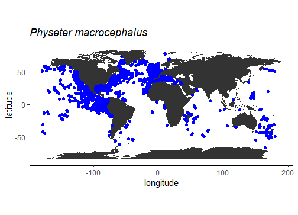

Os dados ainda podem ser melhor refinados. Vale ressaltar que saímos de um total de 78.838 observações iniciais e após poucas etapas obtivemos um conjunto de dados de 16.672 observações. O próximo passo será ainda mais interessante, vamos aprender a unir os conjuntos de dados dos repositórios do GBIF e OBIS. Vamos la?!!

### 4.2 Unificando ocorrências observadas

```
    # ver diferencas gbif e obis
    setdiff(names(cacha_gbif_ok), names(cacha_obis_ok))

    ## [1] "issues"
    ## [2] "sex"
    ## [3] "country"
```

```
    # ver diferencas obis e gbif
    setdiff(names(cacha_obis_ok), names(cacha_gbif_ok))
    ##
    ## [1] "bathymetry"
    ## [2] "flags"
    ## [3] "occurrenceStatus"
    ## [4] "depth"
    ## [5] "locality"
    ## [6] "habitat"
```

Observamos as diferenças entre os dados de ambos os repositórios. Agora iremos unificar todos os dados em um conjunto maior nomeado de `geral_data`.

```
    geral_data <- bind_rows(cacha_gbif_ok %>%
                            mutate(repo = paste0("gbif", row.names(.))),
                          cacha_obis_ok %>%
                            mutate(repo = paste0("obis", row.names(.)))) %>%
      column_to_rownames("repo") %>%
      dplyr::select(decimalLongitude, decimalLatitude, depth) %>%
      distinct() %>%
      rownames_to_column("occ") %>%
      separate(col = "occ", into = c("datasetName", "rn"), sep = 4) %>%
      mutate(scientificName = "Physeter macrocephalus") %>%
      dplyr::select(-rn)
```

```
    # mapear ocorrencias
    ggplot() +
      geom_polygon(data = world, aes(x = long, y = lat, group = group)) +
      coord_fixed() +
      theme_classic() +
      geom_point(data = geral_data, aes(x = decimalLongitude, y = decimalLatitude, color = datasetName)) +
      #theme(legend.title = element_blank()) +
      labs(x = "longitude", y = "latitude", title = expression(italic("Physeter macrocephalus")))
```

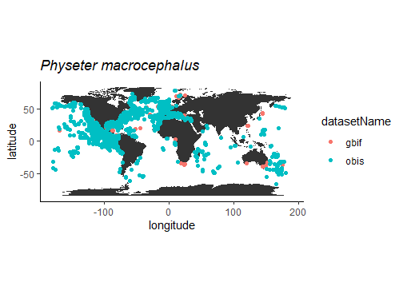